# Final Project- Data 606

Meaghan Burke

May 9, 2018

## **New York City Airbnb**

[figure not shown]

Airbnb NYC Image

```r
library(dplyr)
library(psych)
library(knitr)
library(ggplot2)
```

### **Introduction:**

Airbnb is an online marketplace which lets homeowners rent out their properties or spare rooms to guests. Airbnb takes 3% commission of every booking from hosts, and between 6% and 12% from guests. For my final project, I am going to analyze the public Airbnb data of New York City, http://insideairbnb.com/get-the-data.html, which includes information on listings, reviews and neighborhoods. In my analysis, I look to understand why Airbnb listings are priced differently and where a homeowner could get the biggest ROI. As a frequent user of the platform and a New York City native, I am interest to see if my assumptions on pricing per listing, per neighborhood are accurate.

#### **Hypothesis:**

From the exploration question, hypothesis is defined as follows:

H0: Neighborhoods, room types, minimum nights and reviews have no influence over Airbnb listing prices in NYC

H1: Neighborhoods, room types, minimum nights and reviews have influence over Airbnb listing prices in NYC

#### **Data Source:**

New York City Airbnb Data - **Source: http://insideairbnb.com/get-the-data.html:**

*The Airbnb data was collected by Murry Cox. The dataset is meant to be an independent to allows users to analyze Airbnb usage throughout the world. The snapshot data is regularly scraped/updated by Murry Cox. For this project, data was integrated through reading the .csv files. This is considered an observational study.*

- Reviews data: information and metrics for Airbnb listings in New York City
- Listing data: timestamp review information
- Neighborhoods data: neighborhood listing information

#### **Load The Data**:

```r
#load data
listings <- read.table("C:/Users/burke/OneDrive/Desktop/Data 606-Stats/Project Data 606/Data 606 Data/listings.csv", quote = "", fill=TRUE, header = TRUE, sep = ",", stringsAsFactors=FALSE)

# Data translations- listing data
# Converted all the columns with numbers to numeric
# The raw columns in the listings dataframe were pretty descriptive, kept original

reformatted.listings <-listings %>%
  mutate(price = as.numeric(price, na.rm = TRUE),
         id = as.numeric(id, na.rm = TRUE),
         host_id = as.numeric(host_id, na.rm = TRUE),
         number_of_reviews = as.numeric(number_of_reviews, na.rm = TRUE),
         minimum_nights = as.numeric(minimum_nights, na.rm = TRUE),
         calculated_host_listings_count = as.numeric(calculated_host_listings_count, na.rm = TRUE),
         reviews_per_month = as.numeric(reviews_per_month, na.rm = TRUE),
         availability_365 = as.numeric(availability_365, na.rm = TRUE)) %>%
  filter(price > 0 &
         number_of_reviews > 0 &
         reviews_per_month >0 &
         calculated_host_listings_count > 0 &
         availability_365 >0 &
         id >0)%>%
select(-c(latitude, longitude, id, name, host_id, host_name, last_review,
          reviews_per_month, calculated_host_listings_count,availability_365))
```

#### **Filtered Data**:

*The below table displays all NYC Airbnb listings compiled by Murry Cox.*

Airbnb Listing Data-NYC

| neighbourhood_group | neighbourhood | room_type | price | minimum_nights | number_of_reviews |
| --- | --- | --- | --- | --- | --- |
| Brooklyn | Kensington | Private room | 39 | 1 | 7 |
| Manhattan | Midtown | Entire home/apt | 225 | 1 | 29 |
| Brooklyn | Williamsburg | Private room | 70 | 5 | 27 |
| Brooklyn | Clinton Hill | Entire home/apt | 89 | 1 | 181 |
| Manhattan | Hell’s Kitchen | Entire home/apt | 150 | 1 | 26 |
| Manhattan | Hell’s Kitchen | Entire home/apt | 150 | 1 | 58 |
| Brooklyn | Bedford-Stuyvesant | Private room | 60 | 45 | 51 |
| Brooklyn | Sunset Park | Entire home/apt | 253 | 4 | 1 |
| Manhattan | Hell’s Kitchen | Private room | 79 | 2 | 371 |
| Manhattan | Chinatown | Entire home/apt | 120 | 1 | 146 |

#### **Cases:**

*Each case represents a Airbnb listing in the New York City. There are 21,974 observations in the given data set.*

Dimensions of The Airbnb Dataset

| x |
| --- |
| 21974 |
| 6 |

#### **Explanatory Variables:**

- Number of reviews , numerical
- Minimum night requirement, numerical
- Neighborhood, categorical
- Room type, categorical

#### **Response Variable:**

- Price, numerical

### **Exploratory Analysis:**

#### **Min, Median, Mean, Max, Standard Deviation:**

The below chart, as an initial inspection of the data, suggests that there are differences in between the median prices per listing/room type/neighborhood

Airbnb NYC Listing- Count, Mean and Standard Deviation

| neighbourhood_group | neighbourhood | room_type | Frequency | Min.Value | Median.Value | Mean.Value | Max.Value | SD |
| --- | --- | --- | --- | --- | --- | --- | --- | --- |
| Brooklyn | Sea Gate | Entire home/apt | 1 | 1485 | 1485 | 1485 | 1485 | NaN |
| Manhattan | Tribeca | Entire home/apt | 39 | 151 | 395 | 490 | 1500 | 312 |
| Manhattan | NoHo | Private room | 4 | 85 | 124 | 448 | 1460 | 675 |
| Queens | Holliswood | Entire home/apt | 1 | 414 | 414 | 414 | 414 | NaN |
| Manhattan | SoHo | Entire home/apt | 139 | 95 | 249 | 372 | 2000 | 331 |
| Manhattan | Roosevelt Island | Entire home/apt | 6 | 108 | 150 | 366 | 1400 | 509 |
| Manhattan | Flatiron District | Entire home/apt | 47 | 128 | 265 | 359 | 1050 | 237 |
| Manhattan | Theater District | Entire home/apt | 64 | 95 | 234 | 330 | 2000 | 288 |
| Manhattan | NoHo | Entire home/apt | 35 | 125 | 245 | 319 | 975 | 188 |
| Manhattan | Midtown | Entire home/apt | 442 | 67 | 239 | 314 | 2500 | 253 |
| Manhattan | Nolita | Entire home/apt | 98 | 99 | 244 | 310 | 5000 | 490 |
| Manhattan | Civic Center | Entire home/apt | 8 | 102 | 195 | 297 | 800 | 233 |
| Manhattan | Greenwich Village | Entire home/apt | 149 | 70 | 209 | 285 | 2450 | 285 |
| Brooklyn | Clinton Hill | Entire home/apt | 168 | 70 | 152 | 279 | 8000 | 698 |
| Manhattan | Battery Park City | Entire home/apt | 11 | 205 | 250 | 279 | 450 | 75 |
| Manhattan | West Village | Entire home/apt | 322 | 75 | 225 | 276 | 2590 | 235 |
| Staten Island | South Beach | Entire home/apt | 1 | 275 | 275 | 275 | 275 | NaN |
| Manhattan | Chelsea | Entire home/apt | 369 | 60 | 222 | 274 | 1731 | 188 |
| Queens | Neponsit | Entire home/apt | 1 | 274 | 274 | 274 | 274 | NaN |
| Manhattan | Kips Bay | Entire home/apt | 144 | 99 | 200 | 273 | 1950 | 207 |

#### **Price Analysis:**

From the above chart, it is apparent that there are some outliers in the filtered data set, while the medians are defined by the neighborhood, room type. These intital observations can suggest that the room type, neighborhood could be predictive of listing price as established in the hypothesis.

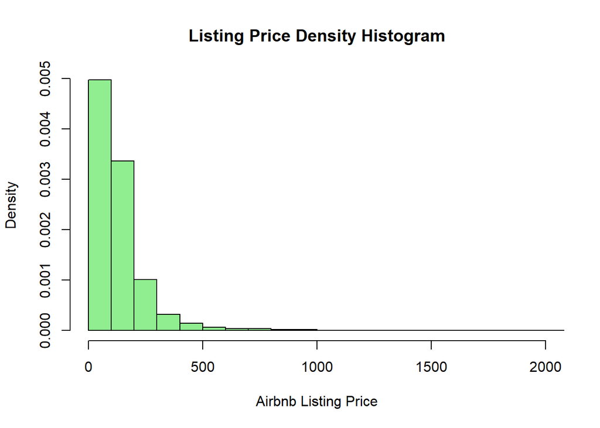

#### **Medians Price Analysis:**

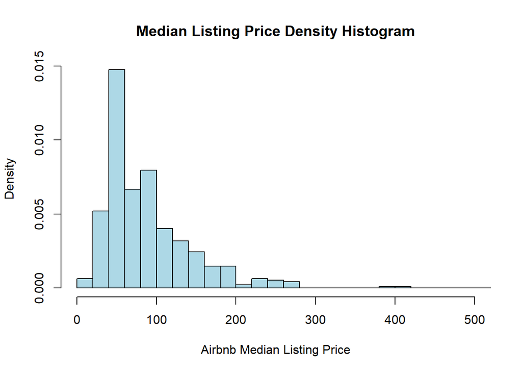

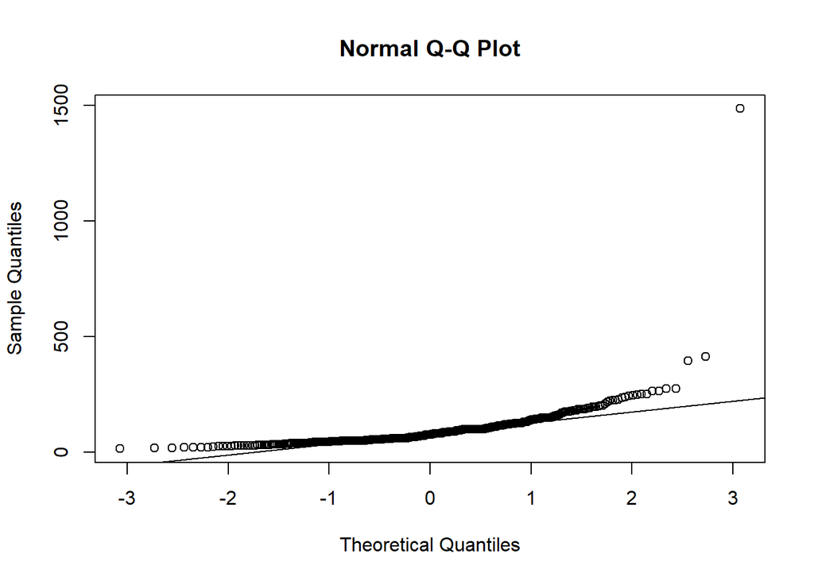

#### **Factor 1) Room Type:**

Room Types

| room_type | Count | mean.price |
| --- | --- | --- |
| Entire home/apt | 11231 | 210 |
| Private room | 10142 | 81 |
| Shared room | 601 | 57 |

```
##   room_type             Count         mean.price
##  Length:3           Min.   :  601   Min.   : 57.0
##  Class :character   1st Qu.: 5372   1st Qu.: 69.0
##  Mode  :character   Median :10142   Median : 81.0
##                     Mean   : 7325   Mean   :116.0
##                     3rd Qu.:10686   3rd Qu.:145.5
##                     Max.   :11231   Max.   :210.0
```

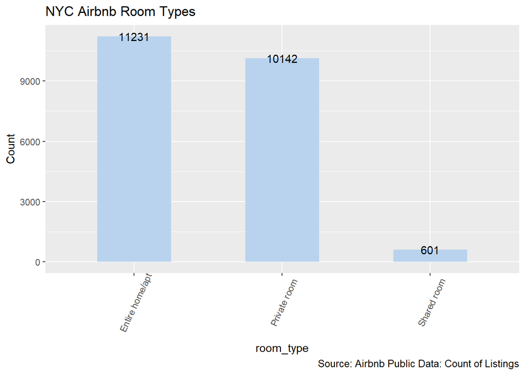

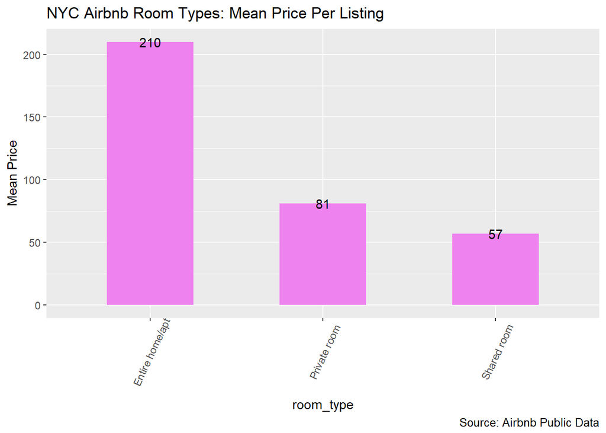

**Room Type Analysis Summary:**

It is apparent, based on the listing counts, that owners are more inclined to list entire properties than that of private rooms or shared rooms. The entire property listings are observed to be more expensive, on average, than the private rooms or shared rooms. This suggests that room type does impact the price of the NYC Airbnb listing. The impact of room type will be later explored in the regression analysis.

#### **Factor 2) Neighborhood:**

Airbnb NYC-Neighborhood Data

| neighbourhood | Count | mean.price |
| --- | --- | --- |
| Williamsburg | 1756 | 149 |
| Bedford-Stuyvesant | 1750 | 105 |
| Harlem | 1375 | 116 |
| Bushwick | 984 | 83 |
| Hell’s Kitchen | 984 | 206 |
| East Village | 884 | 191 |
| Upper West Side | 827 | 207 |
| Upper East Side | 762 | 170 |
| Crown Heights | 712 | 104 |
| East Harlem | 648 | 136 |
| Midtown | 597 | 273 |
| Chelsea | 504 | 230 |
| Lower East Side | 455 | 174 |
| Greenpoint | 442 | 134 |
| Astoria | 421 | 104 |
| West Village | 396 | 253 |
| Washington Heights | 387 | 86 |
| Clinton Hill | 283 | 204 |
| Flatbush | 260 | 91 |
| Prospect-Lefferts Gardens | 250 | 103 |

```
##  neighbourhood          Count          mean.price
##  Length:207         Min.   :   1.0   Min.   : 17.0
##  Class :character   1st Qu.:   5.0   1st Qu.: 71.5
##  Mode  :character   Median :  19.0   Median : 86.0
##                     Mean   : 106.2   Mean   :111.3
##                     3rd Qu.:  74.0   3rd Qu.:134.0
##                     Max.   :1756.0   Max.   :555.0
```

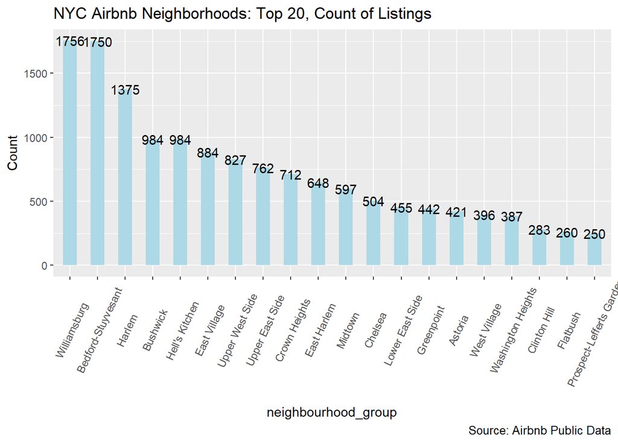

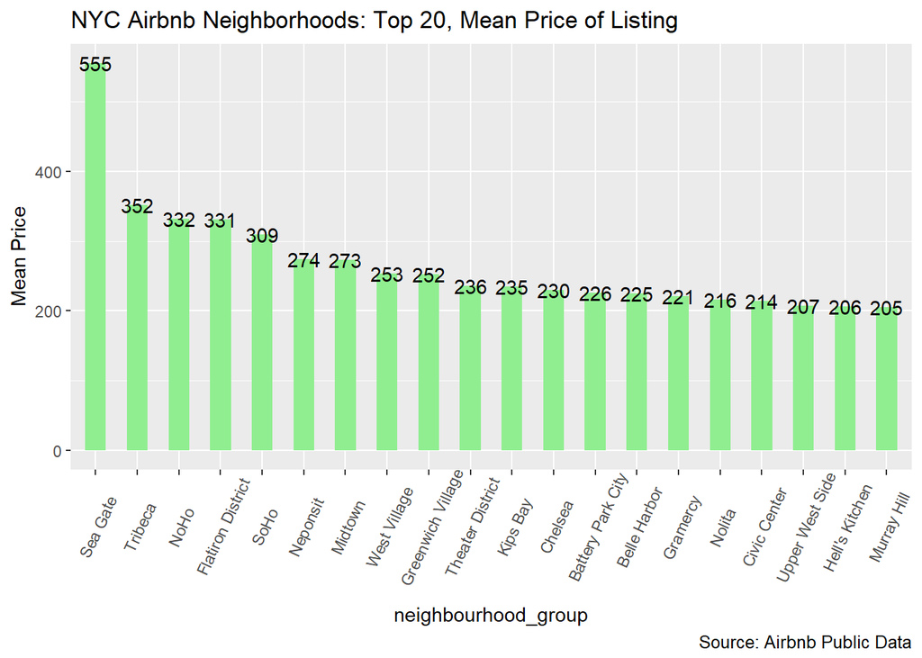

**Neighborhood Analysis Summary:**

The mean price of the listing per neighborhood suggests that there is some correlation between the two variables. The more expensive listing neighborhoods, minus a few outliers, seem to be in Manhattan proper. The true impact of neighborhood will be later explored in the regression analysis.

#### **Exploratory Analysis Initial Insights (Room Types & Neighborhoods):**

It is shown that most property owners are inclined towards listing their entire property. It can also be seen that most of the pricier listings are in Manhattan. Now I will analyze the relationship of prices for different room type and neighborhood on a plotted heat map.

NYC Listings Summary- Room Type & Neighborhood

| room_type | neighbourhood_group | Count | mean.price |
| --- | --- | --- | --- |
| Entire home/apt | Manhattan | 5889 | 248 |
| Entire home/apt | Brooklyn | 4229 | 175 |
| Entire home/apt | Queens | 888 | 142 |
| Entire home/apt | Staten Island | 76 | 124 |
| Entire home/apt | Bronx | 149 | 108 |
| Private room | Manhattan | 3733 | 102 |
| Private room | Brooklyn | 4480 | 73 |
| Shared room | Manhattan | 266 | 67 |
| Private room | Queens | 1495 | 63 |
| Private room | Bronx | 344 | 56 |
| Shared room | Queens | 108 | 56 |
| Private room | Staten Island | 90 | 55 |
| Shared room | Bronx | 20 | 47 |
| Shared room | Brooklyn | 206 | 45 |
| Shared room | Staten Island | 1 | 40 |

```
##   room_type         neighbourhood_group     Count        mean.price
##  Length:15          Length:15           Min.   :   1   Min.   : 40.0
##  Class :character   Class :character    1st Qu.:  99   1st Qu.: 55.5
##  Mode  :character   Mode  :character    Median : 266   Median : 67.0
##                                         Mean   :1465   Mean   : 93.4
##                                         3rd Qu.:2614   3rd Qu.:116.0
##                                         Max.   :5889   Max.   :248.0
```

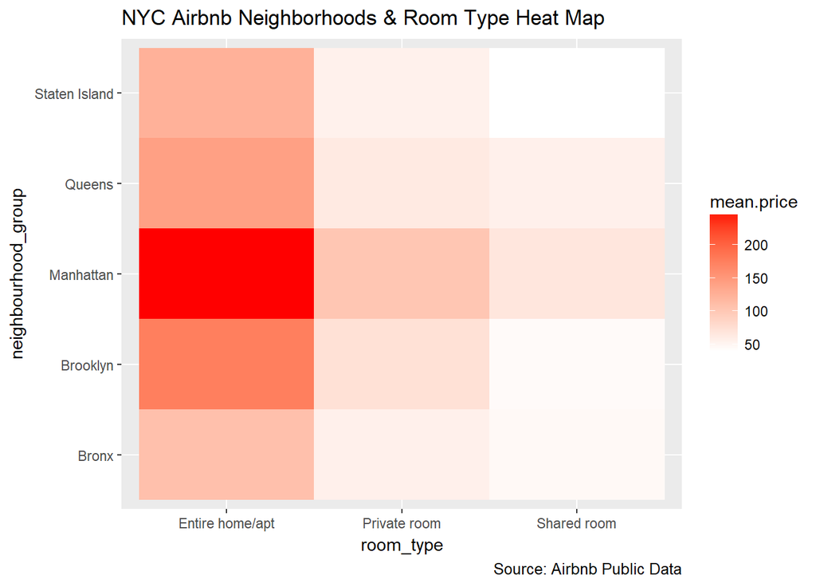

**Heat Map Summary:**

A entire home/apartment in Manhattan will demand the most expensive listing price, on average.

#### **Number of Reviews Distribution:**

NYC Listings Summary- Number of Reviews (Top 20)

| neighbourhood_group | reviews | Count | mean.price |
| --- | --- | --- | --- |
| Staten Island | [0,30] | 113 | 92 |
| Staten Island | (30,60] | 32 | 72 |
| Staten Island | (60,90] | 10 | 93 |
| Staten Island | (90,120] | 5 | 78 |
| Staten Island | (120,150] | 3 | 56 |
| Staten Island | (150,180] | 4 | 56 |
| Queens | [0,30] | 1723 | 94 |
| Queens | (30,60] | 380 | 86 |
| Queens | (60,90] | 177 | 93 |
| Queens | (90,120] | 71 | 76 |
| Queens | (120,150] | 59 | 81 |
| Queens | (150,180] | 28 | 76 |
| Queens | (180,210] | 16 | 56 |
| Queens | (210,240] | 16 | 72 |
| Queens | (240,270] | 4 | 66 |

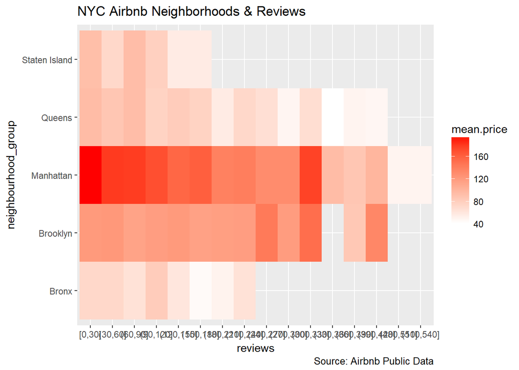

**Review Analysis Summary:**

There does not seem to be a correlation between the number of reviews and the average price of the listings.

#### **Minimum Stay Distribution:**

NYC Listings Summary- Minimum Stay

| stay | Count | mean.price |
| --- | --- | --- |
| (360,370] | 3 | 400 |
| (220,230] | 1 | 315 |
| (590,600] | 1 | 275 |
| (90,100] | 3 | 228 |
| (1.24e+03,1.25e+03] | 1 | 180 |
| (20,30] | 720 | 172 |
| (30,40] | 29 | 165 |
| (60,70] | 2 | 162 |
| (80,90] | 23 | 155 |
| [0,10] | 14255 | 153 |
| (110,120] | 3 | 147 |
| (150,160] | 2 | 115 |
| (10,20] | 355 | 109 |
| (50,60] | 20 | 101 |
| (70,80] | 4 | 97 |
| (170,180] | 6 | 89 |
| (40,50] | 5 | 81 |
| (180,190] | 2 | 78 |
| (290,300] | 1 | 65 |
| (490,500] | 1 | 50 |
| (190,200] | 2 | 45 |
| (210,220] | 1 | 40 |

```
##       stay        Count            mean.price
##  [0,10] : 1   Min.   :    1.00   Min.   : 40.0
##  (10,20]: 1   1st Qu.:    1.25   1st Qu.: 83.0
##  (20,30]: 1   Median :    3.00   Median :131.0
##  (30,40]: 1   Mean   :  701.82   Mean   :146.5
##  (40,50]: 1   3rd Qu.:   16.50   3rd Qu.:170.2
##  (50,60]: 1   Max.   :14255.00   Max.   :400.0
##  (Other):16
```

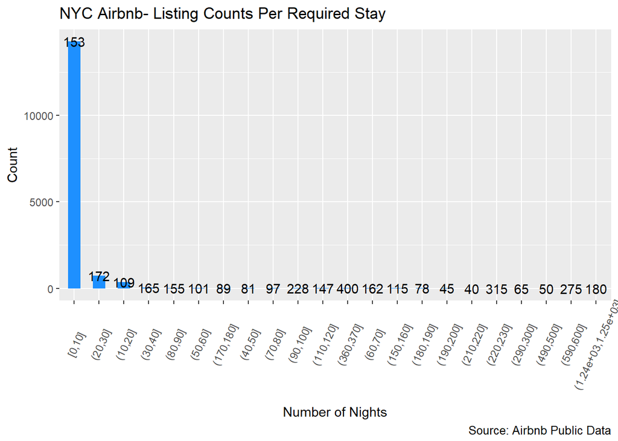

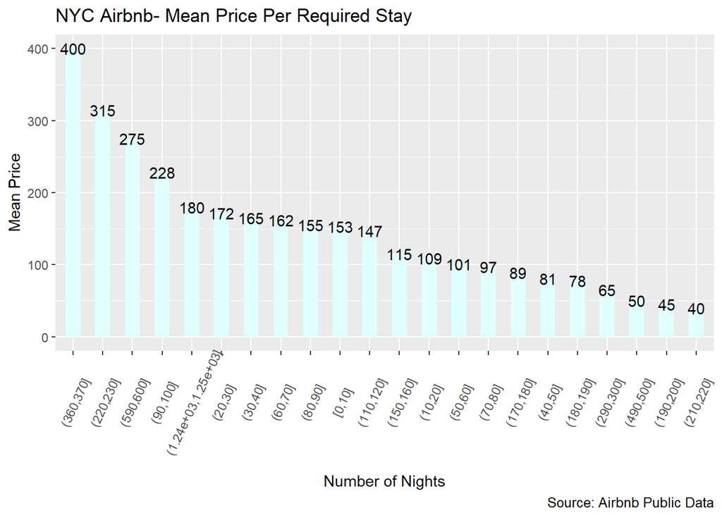

**Minimum Stay Analysis Summary:**

There does not seem to be a huge correlation between the minimum stay requirement and the average price of the listings. However, unsurprisingly, the bulk of the listings are within the 1 - 10 day range.

### **Multiple linear regression:**

```
##
## Call:
## lm(formula = price ~ minimum_nights + number_of_reviews + neighbourhood_group +
##     room_type, data = reformatted.listings)
##
## Residuals:
##    Min     1Q Median     3Q    Max
## -205.8  -54.3  -15.7   16.3 9874.1
##
## Coefficients:
##                                    Estimate Std. Error t value Pr(>|t|)
## (Intercept)                       161.24954    7.82315  20.612  < 2e-16
## minimum_nights                     -0.07189    0.08561  -0.840 0.401023
## number_of_reviews                  -0.17963    0.02710  -6.628 3.48e-11
## neighbourhood_groupBrooklyn        28.29586    7.83107   3.613 0.000303
## neighbourhood_groupManhattan       81.86020    7.83322  10.450  < 2e-16
## neighbourhood_groupQueens          13.33099    8.35163   1.596 0.110455
## neighbourhood_groupStaten Island   -4.89939   15.34555  -0.319 0.749524
## room_typePrivate room            -118.69700    2.39627 -49.534  < 2e-16
## room_typeShared room             -148.76270    7.22615 -20.587  < 2e-16
##
## (Intercept)                      ***
## minimum_nights
## number_of_reviews                ***
## neighbourhood_groupBrooklyn      ***
## neighbourhood_groupManhattan     ***
## neighbourhood_groupQueens
## neighbourhood_groupStaten Island
## room_typePrivate room            ***
## room_typeShared room             ***
## ---
## Signif. codes:  0 '***' 0.001 '**' 0.01 '*' 0.05 '.' 0.1 ' ' 1
##
## Residual standard error: 172.2 on 21965 degrees of freedom
## Multiple R-squared:  0.1477, Adjusted R-squared:  0.1474
## F-statistic: 475.8 on 8 and 21965 DF,  p-value: < 2.2e-16
```

```
## Analysis of Variance Table
##
## Response: price
##                        Df    Sum Sq  Mean Sq  F value    Pr(>F)
## minimum_nights          1    121068   121068    4.084    0.0433 *
## number_of_reviews       1    671150   671150   22.640 1.966e-06 ***
## neighbourhood_group     4  34463398  8615850  290.637 < 2.2e-16 ***
## room_type               2  77578114 38789057 1308.463 < 2.2e-16 ***
## Residuals           21965 651146833    29645
## ---
## Signif. codes:  0 '***' 0.001 '**' 0.01 '*' 0.05 '.' 0.1 ' ' 1
```

### **Conclusion:**

From the initial question: Do neighborhoods, room types, minimum nights and reviews have influence over listing prices in NYC? It can be concluded:

Based on your final model, entire property listings in Manhattan are the most expensive.

**It can be concluded from the plots that prices of listings depends upon following factors:**

- The type of room type. Entire properties are the most expensive, followed by private rooms and shared apartments
- The neighborhood. Manhattan is the most expensive (on average), followed by Brooklyn, Queens, Statin Island and the Bronx
- A higher number of reviews did not guarantee a higher average listing price
- A stay minimum did not guarantee a higher average listing price